# Q & K Box 13.1

Polis et al. (1998) studied the factors that control spider populations on islands in the Gulf of California. We will use part of their data to model the presence/absence of lizards (*Uta*) against the ratio of perimeter to area (P/A, as a measure of input of marine detritus) for 19 islands in the Gulf of California. We fitted a GLM of the presence of *Uta* (binary) against P/A ratio.

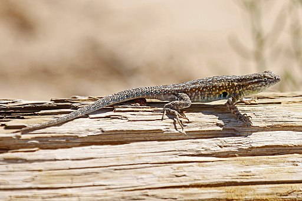

*Uta stansburiana*. Judy Gallagher , via Wikimedia Commons

The data are in Table 1 of the paper, and our data file is here.

Polis, G. A., Hurd, S. D., Jackson, C. T. & Sanchez-Pinero, F. (1998). Multifactor population limitation: Variable spatial and temporal control of spiders on Gulf of California islands. *Ecology*, 79, 490-502.

### Preliminaries

First, load the required packages (car, performance, lmtest) + ggplot2

Import polis data file

```r
polis <- read.csv("../data/polis.csv")
polis
```

| island | paratio | uta | utanum |
| --- | --- | --- | --- |
| Bota | 15.41 | P | 1 |
| Cabeza | 5.63 | P | 1 |
| Cerraja | 25.92 | P | 1 |
| Coronadito | 15.17 | A | 0 |
| Flecha | 13.04 | P | 1 |
| Gemelose | 18.85 | A | 0 |
| Gemelosw | 30.95 | A | 0 |
| Jorabado | 22.87 | A | 0 |
| Mitlan | 12.01 | A | 0 |
| Pata | 11.60 | P | 1 |

[output cut: 9 more lines]

Simple exploratory plot

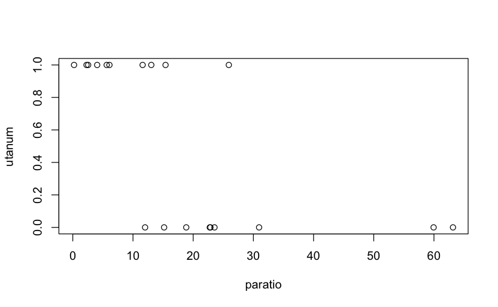

```r
plot(utanum~paratio, data=polis)
```

### Fit glm

```r
polis.glm <- glm(utanum ~ paratio,data=polis,family=binomial)
glance(polis.glm)
```

| null.deviance | df.null | logLik | AIC | BIC | deviance | df.residual | nobs |
| --- | --- | --- | --- | --- | --- | --- | --- |
| 26.3 | 18 | -7.11 | 18.2 | 20.1 | 14.2 | 17 | 19 |

```r
tidy(polis.glm, conf.int=TRUE)
```

| term | estimate | std.error | statistic | p.value | conf.low | conf.high |
| --- | --- | --- | --- | --- | --- | --- |
| (Intercept) | 3.61 | 1.695 | 2.13 | 0.0334 | 1.006 | 8.0421 |
| paratio | -0.22 | 0.101 | -2.18 | 0.0289 | -0.485 | -0.0665 |

Do LR test on slope

```r
anova(polis.glm, test = 'Chisq')
```

```
Analysis of Deviance Table

Model: binomial, link: logit

Response: utanum

Terms added sequentially (first to last)

        Df Deviance Resid. Df Resid. Dev Pr(>Chi)
NULL                       18       26.3
paratio  1     12.1        17       14.2  0.00051 ***
---
Signif. codes:  0 ‘***’ 0.001 ‘**’ 0.01 ‘*’ 0.05 ‘.’ 0.1 ‘ ’ 1
```

Get and plot residuals - deviance residuals first then standardized residuals

```
        Test stat Pr(>|Test stat|)
paratio      0.43             0.51
```

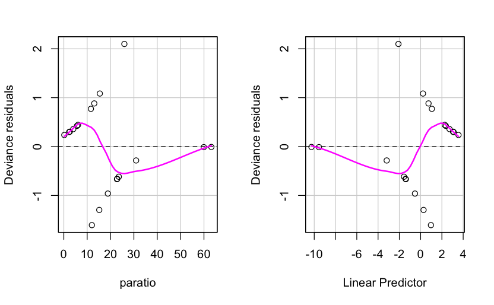

```r
residualPlots(polis.glm, type="deviance")
```

```
        Test stat Pr(>|Test stat|)
paratio      0.43             0.51
```

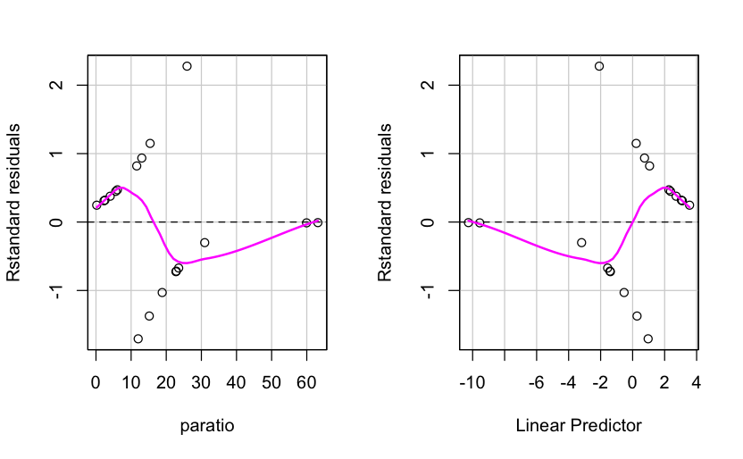

```r
residualPlots(polis.glm, type="rstandard")
```

Check for overdispersion

```r
c(deviance(polis.glm), df.residual(polis.glm))
```

```
[1] 14.2 17.0
```

Check influence diagnostics

```r
rstandard(polis.glm, infl = influence(polis.glm), do.coef = FALSE,
          type = c("deviance"))
```

```
       1        2        3        4        5        6        7        8        9       10       11       12       13       14       15       16       17       18       19
 1.14893  0.44858  2.27765 -1.37313  0.93511 -1.02996 -0.30093 -0.71754 -1.70588  0.81977  0.47127  0.31050  0.37771 -0.01192 -0.00837 -0.72523 -0.67179  0.24631  0.31997
```

```r
augment(polis.glm)
```

| utanum | paratio | .fitted | .resid | .hat | .sigma | .cooksd | .std.resid |
| --- | --- | --- | --- | --- | --- | --- | --- |
| 1 | 15.41 | 0.223 | 1.08443 | 0.109124 | 0.898 | 5.50e-02 | 1.14893 |
| 1 | 5.63 | 2.370 | 0.42278 | 0.111730 | 0.936 | 6.62e-03 | 0.44858 |
| 1 | 25.92 | -2.085 | 2.09860 | 0.151047 | 0.751 | 8.43e-01 | 2.27765 |
| 0 | 15.17 | 0.275 | -1.29637 | 0.108681 | 0.878 | 9.01e-02 | -1.37313 |
| 1 | 13.04 | 0.743 | 0.88217 | 0.110025 | 0.913 | 3.30e-02 | 0.93511 |
| 0 | 18.85 | -0.533 | -0.96114 | 0.129177 | 0.907 | 5.00e-02 | -1.02996 |
| 0 | 30.95 | -3.189 | -0.28417 | 0.108288 | 0.940 | 2.81e-03 | -0.30093 |
| 0 | 22.87 | -1.415 | -0.65943 | 0.155414 | 0.926 | 2.65e-02 | -0.71754 |
| 0 | 12.01 | 0.969 | -1.60675 | 0.112842 | 0.841 | 1.89e-01 | -1.70588 |
| 1 | 11.60 | 1.059 | 0.77160 | 0.114067 | 0.920 | 2.52e-02 | 0.81977 |

[output cut: 9 more lines]

There is one outlier (case 3 - cook D = 0.84) and deleting it changes P value for Wald test but not LR test

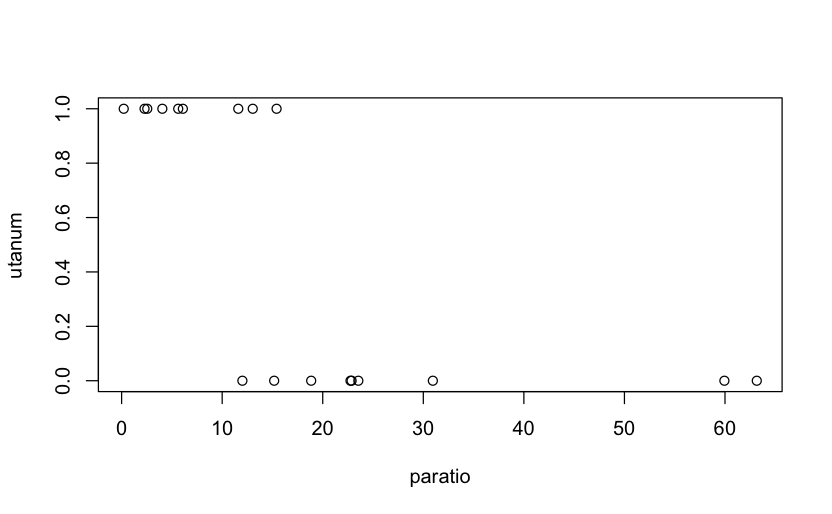

```r
polis1 <- subset(polis, island != "Cerraja")
plot(utanum~paratio, data=polis1)
```

```r
polis1.glm <- glm(utanum ~ paratio,data=polis1,family=binomial)
tidy(polis1.glm)
```

| term | estimate | std.error | statistic | p.value |
| --- | --- | --- | --- | --- |
| (Intercept) | 7.166 | 4.348 | 1.65 | 0.0993 |
| paratio | -0.504 | 0.305 | -1.66 | 0.0979 |

```r
glance(polis1.glm)
```

| null.deviance | df.null | logLik | AIC | BIC | deviance | df.residual | nobs |
| --- | --- | --- | --- | --- | --- | --- | --- |
| 25 | 17 | -3.76 | 11.5 | 13.3 | 7.53 | 16 | 18 |

```r
anova(polis1.glm, test = 'Chisq')
```

```
Analysis of Deviance Table

Model: binomial, link: logit

Response: utanum

Terms added sequentially (first to last)

        Df Deviance Resid. Df Resid. Dev Pr(>Chi)
NULL                       17      24.95
paratio  1     17.4        16       7.53    3e-05 ***
---
Signif. codes:  0 ‘***’ 0.001 ‘**’ 0.01 ‘*’ 0.05 ‘.’ 0.1 ‘ ’ 1
```

Create reduced model for lrtest - same as anova result

```r
polis2.glm <- glm(utanum~+1, data=polis, family=binomial)
lrtest(polis2.glm, polis.glm)
```

```
Likelihood ratio test

Model 1: utanum ~ +1
Model 2: utanum ~ paratio
  #Df LogLik Df Chisq Pr(>Chisq)
1   1 -13.14
2   2  -7.11  1  12.1    0.00051 ***
---
Signif. codes:  0 ‘***’ 0.001 ‘**’ 0.01 ‘*’ 0.05 ‘.’ 0.1 ‘ ’ 1
```

Plot predicted probabilities from original model

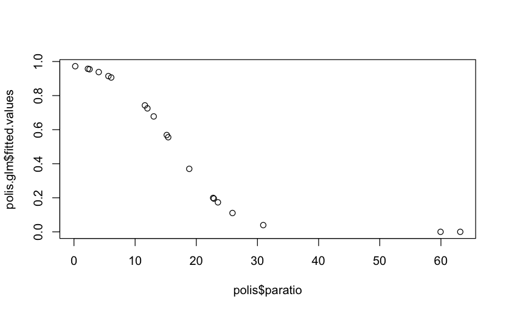

```r
plot(polis.glm$fitted.values~polis$paratio)
```

Get odds ratio with CI

```r
exp(coef(polis.glm))
```

```
(Intercept)     paratio
     36.821       0.803
```

```r
exp(confint.default(polis.glm))
```

```
            2.5 %   97.5 %
(Intercept) 1.328 1021.180
paratio     0.659    0.978
```

Get H-L test and Tjur r<sup>2</sup>

```r
performance_hosmer(polis.glm, n_bins=10)
```

```
# Hosmer-Lemeshow Goodness-of-Fit Test

  Chi-squared: 7.898
           df: 8
      p-value: 0.443
```

```
Summary: model seems to fit well.
```

```r
r2_tjur(polis.glm)
```

```
Tjur's R2
    0.521
```

### Generate figure

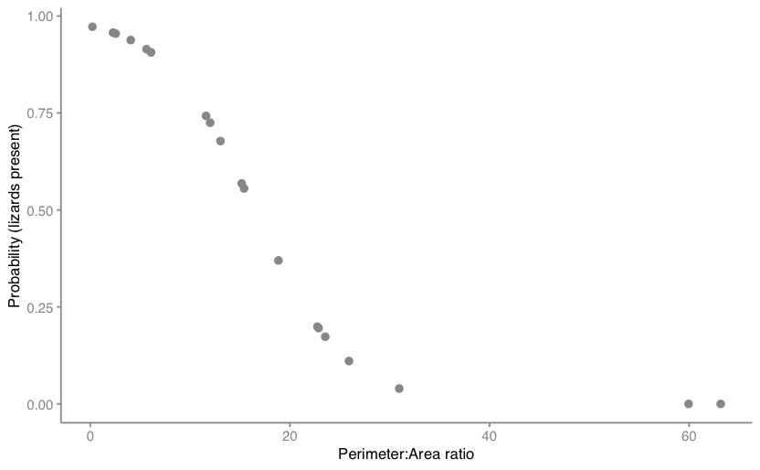

```r
p1<-ggplot(polis.glm,aes(y = polis.glm$fitted.values, x = polis$paratio)) +
  geom_point(color="grey60", size=2, alpha= 1) +
  theme_qk()+labs(x = "Perimeter:Area ratio", y = "Probability (lizards present)",
       )
p1
```